# Homework 11

# Preliminaries

- This file should be in `STAT240/homework/hw11` on your local computer.
- Download `happiness_2019.csv` and `dc_weather.csv` to `STAT240/data`.

# Problem 1

A one-sided hypothesis test of

$$H_A: \beta_1 > 0$$

is performed on a linear model. The p-value of this test is 0.035. What would be the p-value if the same data was used to test the following alternatives?

1. $$H_A: \beta_1 < 0$$

The p-value would be 1 - 0.035 = 0.965.

2. $$H_A: \beta_1 \neq 0$$

The p-value would be 2*0.035 = 0.07

# Problem 2

Continue working with the happiness index vs GDP of countries model from Homework 10.

```r
happiness <- read_csv("../../data/happiness_2019.csv")

# Remove spaces from column names
names(happiness) <- make.names(names(happiness))

happiness_mod <- lm(Score ~ GDP.per.capita, data = happiness)
```

Build and interpret a 98% CI for the true slope of the linear relationship between happiness index and GDP. Does the interval cover 0?

```r
summary(happiness_mod)
```

```
##
## Call:
## lm(formula = Score ~ GDP.per.capita, data = happiness)
##
## Residuals:
##      Min       1Q   Median       3Q      Max
## -2.22044 -0.48361  0.00828  0.48433  1.47409
##
## Coefficients:
##                Estimate Std. Error t value Pr(>|t|)
## (Intercept)      3.3993     0.1353   25.12   <2e-16 ***
## GDP.per.capita   2.2181     0.1369   16.20   <2e-16 ***
## ---
## Signif. codes:  0 '***' 0.001 '**' 0.01 '*' 0.05 '.' 0.1 ' ' 1
##
## Residual standard error: 0.679 on 154 degrees of freedom
## Multiple R-squared:  0.6303, Adjusted R-squared:  0.6278
## F-statistic: 262.5 on 1 and 154 DF,  p-value: < 2.2e-16
```

```r
n <- nrow(happiness)

pt_est <- summary(happiness_mod)$coefficients[2, 1]
se <- summary(happiness_mod)$coefficients[2, 2]
```

The point estimate for the slope is 2.2181, and the standard error is 0.1369. The critical value for 98% confidence is given by the 99th (or 1st) percentile of the T with n - 2 degrees of freedom.

```r
cv <- qt(0.99, df = n-2)

c(pt_est - cv*se, pt_est + cv*se)
```

```
## [1] 1.896305 2.539991
```

We are 98% confident that the true linear relationship between happiness index and GDP per capita is within (1.9, 2.54). This interval is entirely positive and does not cover 0.

# Problem 3

1. Perform a hypothesis test of hypotheses
   $$H_0: \beta_1 = 0 \quad \text{versus}\quad H_A:
   \beta_1 \neq 0$$
   for the slope of the happiness model. What is the test statistic, p-value, and conclusion at the 2% level?

```r
n <- nrow(happiness)
pt_est <- summary(happiness_mod)$coefficients[2, 1]
se <- summary(happiness_mod)$coefficients[2, 2]

test_stat <- (pt_est - 0) / se
```

The test statistic is
$$\frac{\hat{\beta}_1 - 0}{\hat{se}(\hat{\beta}_1)}
= \frac{2.2181}{0.1369} = 16.2$$
Under the null, this comes from a T distribution with $n - 2 = 154$ degrees of freedom. So our p-value is the area outside of -16.2 and 16.2 on the $T_{n-2}$ curve.

```r
2*pt(test_stat, df = n-2, lower.tail = F)
```

```
## [1] 4.315481e-35
```

We have a very small p-value which is much smaller than $\alpha = 0.02$. We reject the null since we have strong evidence that the true slope is nonzero.

2. How do the results of the hypothesis test in problem 3 relate to the results of the confidence interval in problem 2?

Both methods return a significant result regarding the value 0. We rejected the null value of 0 at the 2% level. If we look at the 98% confidence interval, we see that 0 is not contained within the interval. Both methods show that our data is not consistent with $\beta_1 = 0$.

# Problem 4

1. Complete a test at the 5% level to determine whether the slope of the linear relationship between gas consumption and temperature is less than -0.3. Include hypotheses, test statistic, p-value, and a conclusion.

```r
est_slope <- -0.39324
se <- 0.01959

test_stat <- (est_slope - (-0.3)) / se
test_stat
```

```
## [1] -4.759571
```

The p-value for this test is the area below our test statistic on the T with $n - 2 = 24$ degrees of freedom.

```r
n <- 26

pt(test_stat, df = n-2)
```

```
## [1] 3.826478e-05
```

We have a small p-value less than the significance level of 0.05, so we reject the null hypothesis. We have evidence that the true slope is less than -0.3.

2. The 11th point in the data has a residual value of 0.17. Does the linear model overestimate or underestimate the gas consumption on that day?

A positive residual ($y_i - \hat{y}_i$) means that the observed point lies above the line, so the linear model underestimates the actual gas consumption on that day.

3. The outside low temperature on the day when the 11th point of data was recorded was 5.4 degrees C. How much gas was actually consumed on this day?

4. We know that the standard deviation of the temperature measurements are larger than the standard deviation of the gas consumption measurements. Which of the four statements is true about the correlation between temperature and gas consumption, and why?
- The correlation is between -1 and -0.393.
- The correlation is between -0.393 and 0.
- The correlation is between 0 and 0.393.
- The correlation is between 0.393 and 1.

The third and fourth statements must be false, since we know that a negative linear model slope means the correlation between x and y are negative. From the formula for slope, we have
$$-0.393 \;=\;
r\Big(\frac{s_Y}{s_X}\Big) \quad \rightarrow \quad r \;=\;
\Big(\frac{s_X}{s_Y}\Big)(-0.393)$$
From the statement of the problem, $\frac{s_X}{s_Y}$ is a number greater than 1, so the correlation must have a larger magnitude than the slope of -0.393. The first statement is correct.

# Problem 5

Which of the following conditions lead to a smaller prediction error? Briefly explain your chocies.

- A smaller sample size vs a larger sample size

A larger sample size results in a smaller standard error. Having more data means that our model is more reliable.

- A smaller value of $\sigma$ vs a larger value of $\sigma$

A smaller value of $\sigma$ results in a smaller standard error. When the points are less spread out around the line, our linear model does a better job of prediction.

- Predicting closer to $\bar{x}$ vs predicting further from $\bar{x}$

Predicting closer to $\bar{x}$ results in a smaller standard error. Our linear model is more reliable in the center of our original data.

- A smaller variance vs a larger variance in the original $X$ data

A larger variance in the original $X$ data results in a smaller standard error. If our original model covers a wider “range” of possible x values, it does a better job of prediction.

# Problem 6

Consider predicting the happiness index of a country with 1 GDP per capita.

1. Build a *prediction interval* for the happiness index of a new country with $x^* = 1$ GDP per capita. You can use the `predict()` function.

```r
predict(happiness_mod, newdata = tibble(GDP.per.capita = 1),
        interval = "prediction")
```

```
##        fit      lwr      upr
## 1 5.617493 4.271502 6.963485
```

2. Build a *confidence interval* for the height of the regression line at $x^* = 1$. You can use the `predict()` function.

```r
predict(happiness_mod, newdata = tibble(GDP.per.capita = 1),
        interval = "confidence")
```

```
##        fit     lwr      upr
## 1 5.617493 5.50707 5.727917
```

3. Explain the difference in how the prediction and confidence intervals are calculated.

A prediction interval predicts the y value for a single new observation. A confidence interval predicts the *average* y value for a certain value of x, which results in a narrower interval. The standard error of the prediction interval for $|x^* $ is larger than the standard error of the confidence interval for $E(\hat{y}|x^*)$

# Problem 7

The file `dc_weather.csv` contains weather data for Washington, DC from August 2018 to August 2024.

```r
weather <- read_csv("../../data/dc_weather.csv")
```

1. Make a plot of minimum temperature (in C) on the x axis versus dew point on the y axis. Comment on the shape of the data.

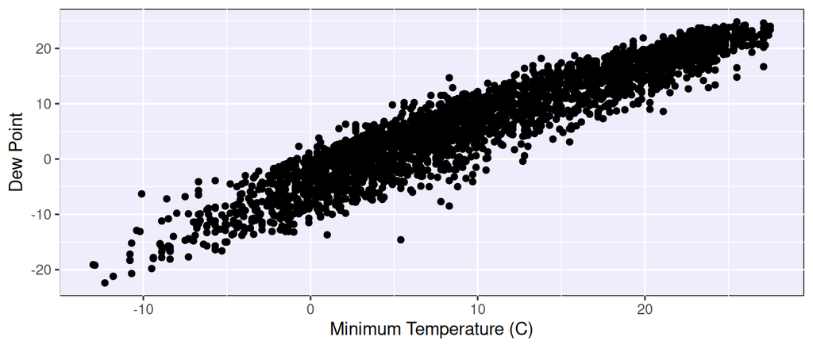

```r
ggplot(weather, aes(x = tempmin, y = dew)) +
  geom_point() +
  labs(x = "Minimum Temperature (C)", y = "Dew Point")
```

There appears to be a strong, positive linear relationship between the two variables.

2. Use R’s `lm()` to fit a linear model for dew point in terms of minimum temperature. Perform a residual analysis to assess the validity of this model.

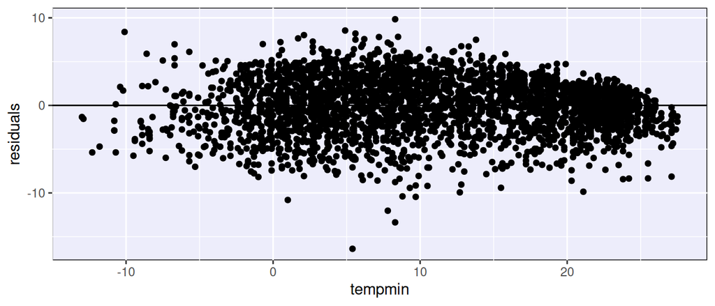

```r
weather_mod <- lm(dew ~ tempmin, data = weather)

# Build residual plot
weather %>%
  mutate(residuals = resid(weather_mod)) %>%
  ggplot(aes(x = tempmin, y = residuals)) +
  geom_point() +
  geom_hline(yintercept = 0)
```

The residual plot suggests that X and Y have a linear relationship, and the residuals are approximately normal around 0. There may be a few concerns with constant variance for higher values of minimum temperature.

# Problem 8

We want to test whether the slope of the linear relationship between minimum temperature and dew point is greater than 1. Write hypotheses corresponding to the question of interest and carry out the test on the weather data. Make a conclusion with $\alpha = 0.05$.

The wording “greater than 1” suggests a pair of one-sided hypotheses. The alternative represents the true slope being greater than 1. This gives hypotheses
$$H_0: \beta_1 = 1 \quad \text{versus} \quad H_A:
\beta_1 > 1$$

```r
n <- nrow(weather)
pt_est <- summary(weather_mod)$coefficients[2, 1]
se <- summary(weather_mod)$coefficients[2, 2]

test_stat <- (pt_est - 1) / se
```

The test statistic is
$$\frac{\hat{\beta}_1 - 1}{\hat{se}(\hat{\beta}_1)}
= \frac{0.062498}{0.005787} = 10.8$$
Under the null, this comes from a T distribution with $n - 2 = 3317$ degrees of freedom. Since our alternative suggests we are looking for a result in the positive direction, our p-value is the area on a $T_{3317}$ curve *above* 10.8.

```r
pt(test_stat, df = n-2, lower.tail = F)
```

```
## [1] 4.814404e-27
```

Our p-value is virtually 0, so we reject the null. We have evidence that the linear relationship between dew point and minimum temperature is greater than 1.